# התמכרות סטודנטים למדיה חברתית

[figure not shown]

### מגישים:

- `דניאל דוידוב`
- `אביב שיקאר`

### מספר הפרויקט : 15

### תיאור הפרויקט:

מערך הנתונים כולל מידע דמוגרפי של סטודנטים, הרגלי השימוש שלהם במדיה החברתית ומדדים הקשורים להשפעות השימוש על בריאות נפשית, תפקוד אקדמי ועוד. מטרת הפרויקט היא לחקור כיצד רמות השימוש במדיה החברתית משפיעות על היבטים שונים בחייהם ולזהות דפוסים וקשרים בין המשתנים. הניתוח יתבצע באמצעות טכניקות סטטיסטיות, המחשות גרפיות ובחינת קורלציות במטרה לחשוף מגמות ותובנות משמעותיות לגבי התמכרות והשפעותיה.

### קישור למערך הנתונים:

https://www.kaggle.com/datasets/adilshamim8/social-media-addiction-vs-relationships

### הסבר על מקור של המערך נתונים

מערך הנתונים כולל נתונים אנונימיים על הרגלי השימוש במדיה החברתית והשפעותיהם על סטודנטים, כגון ביצועים אקדמיים, בריאות נפשית ודינמיקה של מערכות יחסים. הנתונים נאספו באמצעות סקרים שהופצו בקרב סטודנטים במוסדות חינוך שונים בעולם.

## תוכן עניינים

- הכרת המערך נתונים
- מסקנה ראשונה
- מסקנה שנייה
- מסקנה שלישית
- סיכום

### הכרת המערך נתונים

- ייבוא ספריות וקריאת הדאטה
- הכרת העמודות
- בדיקת הקשרים בין עמודות מספריות שונות
- התפלגות של עמודות קטגוריות

```python
import pandas as pd
import numpy as np
import matplotlib.pyplot as plt
import seaborn as sns
import matplotlib.pyplot as plt
```

```python
url = "https://raw.githubusercontent.com/danieldavidov/Aviv_Daniel_project_EDA/refs/heads/main/%D7%94%D7%AA%D7%9E%D7%9B%D7%A8%D7%95%D7%AA%20%D7%A1%D7%98%D7%95%D7%93%D7%A0%D7%98%D7%99%D7%9D.csv"
df = pd.read_csv(url)
df.head(10)
```

|  | Student_ID | Age | Gender | Academic_Level | Country | Avg_Daily_Usage_Hours | Most_Used_Platform | Affects_Academic_Performance | Sleep_Hours_Per_Night | Mental_Health_Score | Relationship_Status | Conflicts_Over_Social_Media | Addicted_Score |
| --- | --- | --- | --- | --- | --- | --- | --- | --- | --- | --- | --- | --- | --- |
| 0 | 1 | 19 | Female | Undergraduate | Bangladesh | 5.2 | Instagram | Yes | 6.5 | 6 | In Relationship | 3 | 8 |
| 1 | 2 | 22 | Male | Graduate | India | 2.1 | Twitter | No | 7.5 | 8 | Single | 0 | 3 |
| 2 | 3 | 20 | Female | Undergraduate | USA | 6.0 | TikTok | Yes | 5.0 | 5 | Complicated | 4 | 9 |
| 3 | 4 | 18 | Male | High School | UK | 3.0 | YouTube | No | 7.0 | 7 | Single | 1 | 4 |
| 4 | 5 | 21 | Male | Graduate | Canada | 4.5 | Facebook | Yes | 6.0 | 6 | In Relationship | 2 | 7 |
| 5 | 6 | 19 | Female | Undergraduate | Australia | 7.2 | Instagram | Yes | 4.5 | 4 | Complicated | 5 | 9 |
| 6 | 7 | 23 | Male | Graduate | Germany | 1.5 | LinkedIn | No | 8.0 | 9 | Single | 0 | 2 |
| 7 | 8 | 20 | Female | Undergraduate | Brazil | 5.8 | Snapchat | Yes | 6.0 | 6 | In Relationship | 2 | 8 |
| 8 | 9 | 18 | Male | High School | Japan | 4.0 | TikTok | No | 6.5 | 7 | Single | 1 | 5 |
| 9 | 10 | 21 | Female | Graduate | South Korea | 3.3 | Instagram | No | 7.0 | 7 | In Relationship | 1 | 4 |

```python
df.shape
```

```
(705, 13)
```

```python
df.columns
```

```
Index(['Student_ID', 'Age', 'Gender', 'Academic_Level', 'Country',
       'Avg_Daily_Usage_Hours', 'Most_Used_Platform',
       'Affects_Academic_Performance', 'Sleep_Hours_Per_Night',
       'Mental_Health_Score', 'Relationship_Status',
       'Conflicts_Over_Social_Media', 'Addicted_Score'],
      dtype='object')
```

```python
numeric_columns = df.select_dtypes(include=['int64', 'float64']).columns.tolist()
categorical_columns = df.select_dtypes(include=['object', 'category']).columns.tolist()
print(f"מספר עמודות מספריות: {len(numeric_columns)}\nמספר עמודות קטגוריות: {len(categorical_columns)}")
```

```
מספר עמודות מספריות: 7
מספר עמודות קטגוריות: 6
```

כעת לאחר הכרה ראשונית של העמודות נבצע קורלציה בין כל העמודות המספריות לצורך בחינת קשרים שונים

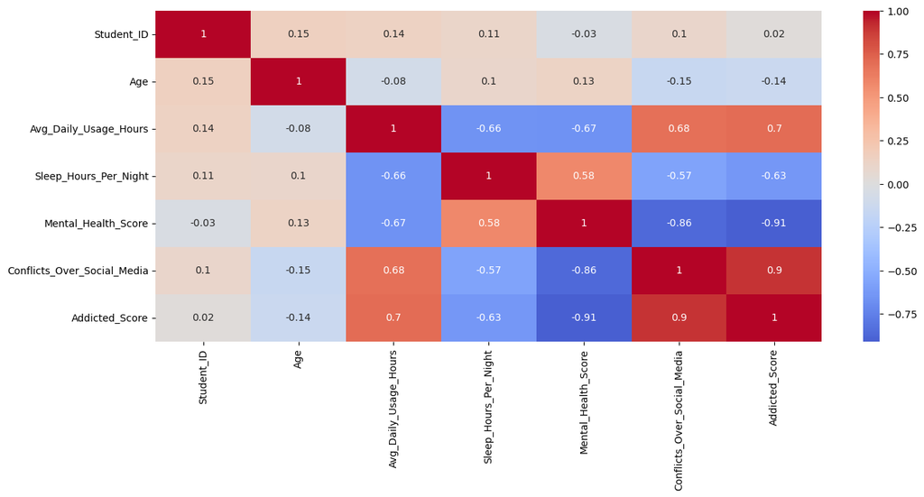

```python
#בדיקת קורלציות בין כל עמודות המספריות בדאטה
correlation_matrix = df.corr(method = 'kendall', numeric_only=True).round(2)
plt.figure(figsize=(15,6))
sns.heatmap(correlation_matrix, cmap='coolwarm', center=0, annot = True)
```

בדיקת התפלגות כל העמודות הקטגוריות

```python
categorical_cols = df.select_dtypes(include=['object']).columns
for i in range (len(categorical_cols)):
    print(df[categorical_cols[i]].value_counts().reset_index())
```

```
   Gender  count
0  Female    353
1    Male    352
  Academic_Level  count
0  Undergraduate    353
1       Graduate    325
2    High School     27
       Country  count
0        India     53
1          USA     40
2       Canada     34
3      Denmark     27
4      Ireland     27
..         ...    ...
105    Uruguay      1
```

[output cut: 26 more lines]

- מכיוון שמספר המשיבים מכל מדינה קטן יחסית לכמות המדינות הכוללת, לא ניתן התייחסות לעמודת המדינות מאחר שאין בה ערך סטיסטי מהימן.

## ניתוח ראשון: השפעת הפלטפורמה בשימוש עיקרי על היבטים שונים באורח חיים

- התפלגות הפלטפורומות עם השימוש הגבוה ביותר
- גרפים של שלושת הפלטפורמות בשימוש הגבוה ביותר
- מסקנות

נבדוק את התפלגות עמודת הפלטפורמה בשימוש מירבי

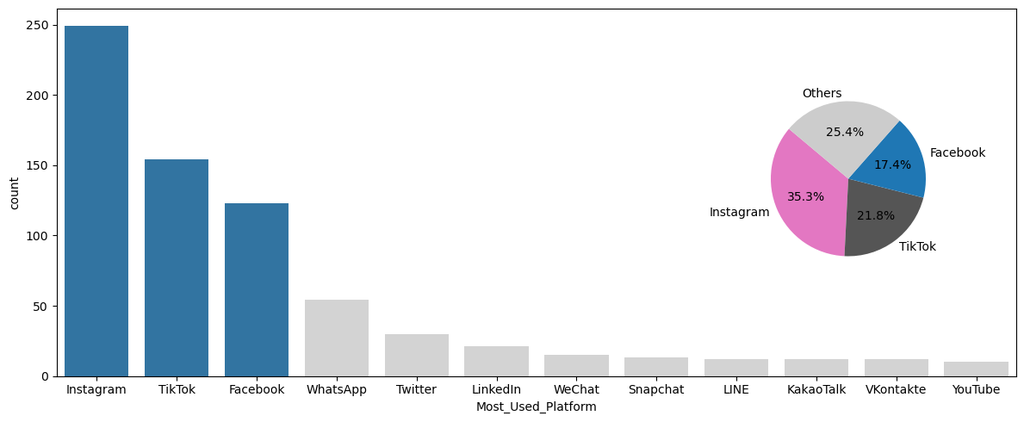

```python
# Count platforms
platform_counts = df['Most_Used_Platform'].value_counts()
top3 = platform_counts.nlargest(3).index

# Barplot colors: top 3 platforms colored, rest in gray
colors = ['#1f77b4' if platform in top3 else 'lightgray' for platform in platform_counts.index]

# Main figure and axes
fig, ax = plt.subplots(figsize=(12, 5))
sns.countplot(data=df, x='Most_Used_Platform', order=platform_counts.index, palette=colors, ax=ax)

# Data for pie chart
highlighted_counts = platform_counts[platform_counts.index.isin(top3)]
other_count = platform_counts[~platform_counts.index.isin(top3)].sum()
final_counts = pd.concat([
    highlighted_counts,
    pd.Series({'Others': other_count})
])

# Pie chart colors
pie_colors = {
    top3[0]: '#e377c2',
    top3[1]: '#555555',
    top3[2]: '#1f77b4',
    'Others': '#cccccc'
}
pie_color_list = [pie_colors[label] for label in final_counts.index]

# Add inset axes for pie chart
inset_ax = fig.add_axes([0.7, 0.35, 0.25, 0.45])  # [left, bottom, width, height]
inset_ax.pie(final_counts, labels=final_counts.index, autopct='%1.1f%%', colors=pie_color_list, startangle=140)

plt.tight_layout()
plt.show()
```

ניתן לראות על פי הגרף שרוב העונים של הסקר ציינו שלושה פלטפורומות שונות שהם בשימוש מרכזי אצלם, ולכן נעסוק בניתוח רק של הפלטפורמות האלו

#### ניתוח השפעת פלפטורמה בשימוש מירבי על היבטים שונים של התמכרות ואורח חיים

כעת נבדוק את השפעת הפלטפורמה בשימוש גבוה על היבטים שונים של התמכרות נבצע קיבוץ נתונים לפי הפלטפורמה בשימוש עיקרי על כמה עמודות שונות ונבצע ממוצע של כל עמודה

```python
#קיבוץ לפי שלושת הפלטפורמות המובילות
platforms = ['Facebook', 'Instagram', 'TikTok']
filtered_platforms_df = df[df['Most_Used_Platform'].isin(platforms)]
Q1_df = filtered_platforms_df.groupby('Most_Used_Platform')[['Addicted_Score', 'Avg_Daily_Usage_Hours', 'Sleep_Hours_Per_Night','Mental_Health_Score']].mean().reset_index()
Q1_df
```

|  | Most_Used_Platform | Addicted_Score | Avg_Daily_Usage_Hours | Sleep_Hours_Per_Night | Mental_Health_Score |
| --- | --- | --- | --- | --- | --- |
| 0 | Facebook | 5.666667 | 4.507317 | 7.360163 | 6.715447 |
| 1 | Instagram | 6.554217 | 4.872289 | 7.021285 | 6.124498 |
| 2 | TikTok | 7.428571 | 5.346104 | 6.362987 | 5.714286 |

#### הצגה גרפית

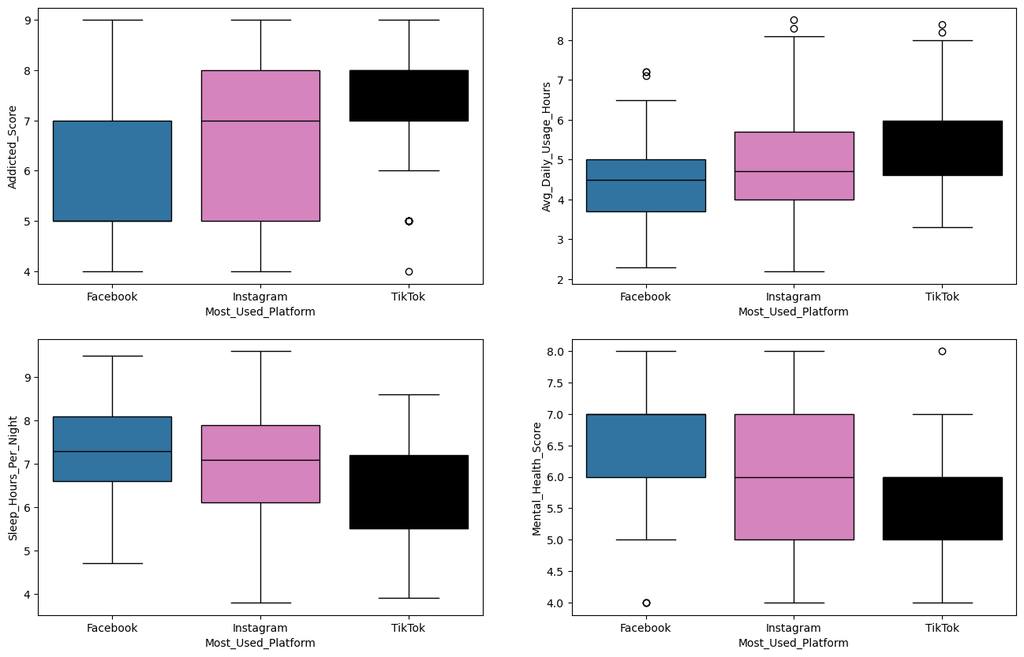

```python
platforms = ['Facebook', 'Instagram', 'TikTok']
platform_palette = {
    'Facebook': '#1f77b4',   # כחול
    'Instagram': '#e377c2',  # ורוד
    'TikTok': '#000000',     # שחור
    'WhatsApp': "Green",
}

fig, ax = plt.subplots(2, 2, figsize=(16, 10), sharey = False)

sns.boxplot(data=df, x='Most_Used_Platform', y='Addicted_Score', ax=ax[0,0], palette=platform_palette, order=platforms)
sns.boxplot(data=df, x='Most_Used_Platform', y='Sleep_Hours_Per_Night',ax=ax[1,0], palette=platform_palette, order=platforms)
sns.boxplot(data=df, x='Most_Used_Platform', y='Avg_Daily_Usage_Hours',ax=ax[0,1], palette=platform_palette, order=platforms)
sns.boxplot(data=df, x='Most_Used_Platform', y='Mental_Health_Score',ax=ax[1,1], palette=platform_palette, order=platforms)
```

כעת נבחן את השפעת הפלטפורמה בשימוש עיקרי על הלימודים

```python
counts_platform_affect = filtered_platforms_df.groupby(['Most_Used_Platform', 'Affects_Academic_Performance']).size().reset_index(name='Count')
# הוספת עמודת אחוזים מתוך כל פלטפורמה
counts_platform_affect['Percentage'] = counts_platform_affect.groupby('Most_Used_Platform')['Count'].transform(lambda x: 100 * x / x.sum())
counts_platform_affect
```

|  | Most_Used_Platform | Affects_Academic_Performance | Count | Percentage |
| --- | --- | --- | --- | --- |
| 0 | Facebook | No | 86 | 69.918699 |
| 1 | Facebook | Yes | 37 | 30.081301 |
| 2 | Instagram | No | 77 | 30.923695 |
| 3 | Instagram | Yes | 172 | 69.076305 |
| 4 | TikTok | No | 10 | 6.493506 |
| 5 | TikTok | Yes | 144 | 93.506494 |

#### הצגה גרפית

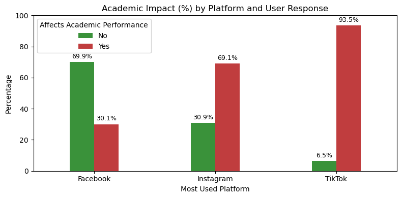

```python
impact_palette = {
    'Yes': '#d62728',  # אדום
    'No': '#2ca02c'    # ירוק
}
plt.figure(figsize=(8, 4))
ax = sns.barplot(
    data=counts_platform_affect,
    x='Most_Used_Platform',
    y='Percentage',
    hue='Affects_Academic_Performance',
    palette=impact_palette,
    width=0.4
)
for container in ax.containers:
    ax.bar_label(container, fmt='%.1f%%', padding=3, fontsize=9)

# כותרות
plt.title("Academic Impact (%) by Platform and User Response")
plt.xlabel("Most Used Platform")
plt.ylabel("Percentage")
plt.ylim(0, 100)
plt.legend(title="Affects Academic Performance")
plt.tight_layout()
plt.show()
```

### מסקנות:

- קיימים הבדלים ברמות ההתמכרות בין משתמשים על פי הפלטפורמה העיקרית בשימוש.
- משתמשי TikTok מדווחים על רמות התמכרות גבוהות יותר, וכן על שימוש יומי ממושך יותר בטלפון לעומת משתמשי Facebook.
- בנוסף, משתמשי TikTok ישנים פחות בממוצע ומצבם הנפשי פחות טוב לעומת משתמשי Facebook.
- בקרב משתמשי Facebook, רוב הנשאלים טוענים כי השימוש בפלטפורמה אינו פוגע בתפקוד הלימודי שלהם.
- לעומת זאת, רוב משתמשי Instagram ו-TikTok מדווחים כי השימוש במדיה כן משפיע לרעה על הלימודים שלהם.

## ניתוח שני: השפעת שעות שימוש יומי במדיה חברתית על היבטים שונים

- התפלגות עמודת שעות שימוש בממוצע ביום
- השפעה על תפקוד לימודי
- השפעה על הרגלי השינה
- מסקנות

#### תחילה נציג את התפלגות עמודת ממוצע שעות שימוש היומי

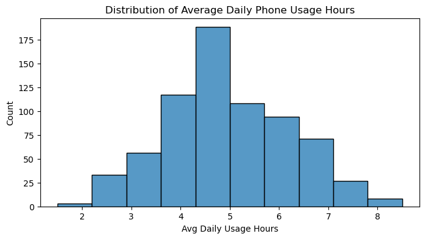

```python
plt.figure(figsize=(8, 4))

sns.histplot(df['Avg_Daily_Usage_Hours'], bins=10)
plt.title("Distribution of Average Daily Phone Usage Hours")
plt.xlabel("Avg Daily Usage Hours")
plt.ylabel("Count")
```

#### ניתוח השפעת שעות השימוש היומי על התפקוד הלימודי

```python
# יצירת טווחים
bins = [0,4,6,9]
labels = ['0-4', '4-6', '6-9']
df['Usage_Hours_Group'] = pd.cut(df['Avg_Daily_Usage_Hours'], bins=bins, labels=labels, include_lowest=True)

# ספירת תשובות לכל קבוצה
grouped_Usage_Hours_Group = (
    df.groupby(['Usage_Hours_Group', 'Affects_Academic_Performance'])
    .size()
    .reset_index(name='Count')
)

# הוספת אחוזים
grouped_Usage_Hours_Group['Percentage'] = grouped_Usage_Hours_Group['Count'] / grouped_Usage_Hours_Group.groupby('Usage_Hours_Group')['Count'].transform('sum') * 100
grouped_Usage_Hours_Group
```

|  | Usage_Hours_Group | Affects_Academic_Performance | Count | Percentage |
| --- | --- | --- | --- | --- |
| 0 | 0-4 | No | 143 | 84.615385 |
| 1 | 0-4 | Yes | 26 | 15.384615 |
| 2 | 4-6 | No | 109 | 27.735369 |
| 3 | 4-6 | Yes | 284 | 72.264631 |
| 4 | 6-9 | No | 0 | 0.000000 |
| 5 | 6-9 | Yes | 143 | 100.000000 |

#### הצגה גרפית

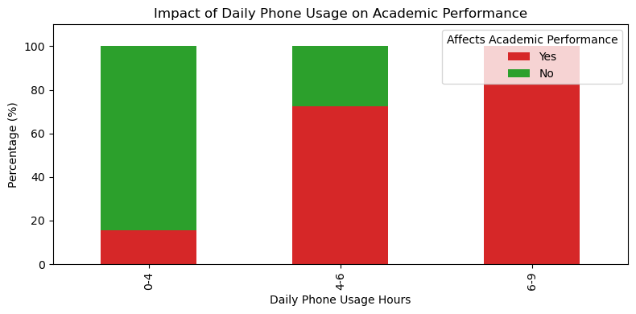

```python
# סידור העמודות לפי הסדר הרצוי
pivot_df = grouped_Usage_Hours_Group.pivot(index='Usage_Hours_Group',
                                            columns='Affects_Academic_Performance',
                                            values='Percentage')
# הבטחת סדר העמודות
pivot_df = pivot_df[['Yes', 'No']]

# ציור הגרף
pivot_df.plot(kind='bar',
              stacked=True,
              color=['#d62728', '#2ca02c'],  # ירוק ל-Yes, אדום ל-No
              figsize=(8, 4))

plt.title("Impact of Daily Phone Usage on Academic Performance")
plt.ylabel("Percentage (%)")
plt.xlabel("Daily Phone Usage Hours")
plt.legend(title="Affects Academic Performance")
plt.ylim(0, 110)
plt.tight_layout()
plt.show()
```

#### השפעת שעות השימוש היומי על שעות השינה

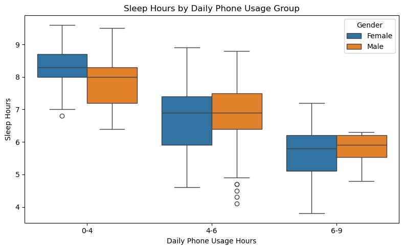

```python
plt.figure(figsize=(8, 5))
sns.boxplot(data=df, x='Usage_Hours_Group', y='Sleep_Hours_Per_Night',hue = "Gender")
plt.title("Sleep Hours by Daily Phone Usage Group")
plt.xlabel("Daily Phone Usage Hours")
plt.ylabel("Sleep Hours")
plt.tight_layout()
plt.show()
```

### מסקנות

- אנשים בעלי שימוש רב במדיה חברתית ביום מעידים על השפעה על הלימודים שלהם
- שעות שימוש בטלפון ביום בא על חשבון שעות השינה
- אין הבדל משמעותי בין נשים לגברים בהשפעת שעות שימוש בממצוע ביום במדיה חברתית על שעות שינה

## ניתוח שלישי: אפיון המכורים ביותר

- התפלגות עמודת ציון רמת התמכרות
- שיעור מכורים לפי קבוצת גיל ומגדר
- שיעור מכורים לפי רמה לימודית
- מסקנות

##### תחילה נבדוק את התפלגות עמודת ציון רמת התמכרות

[figure not shown]

```python
plt.figure(figsize=(8, 4))

sns.histplot(df['Addicted_Score'],discrete= True ,bins=10, )
plt.title("Distribution of Average Daily Phone Usage Hours")
plt.xlabel("Avg Daily Usage Hours")
plt.ylabel("Count")
```

```python
df['Is_Highly_Addicted'] = df['Addicted_Score'] >= 7
```

#### ניתוח שיעור המכורים לפי גיל ומגדר

נוסיף עמודה חדשה של קבוצת גיל ומגדר

```python
# יצירת קבוצות גיל-מגדר
def classify_group(row):
    if row['Age'] >= 18 and row['Age'] <= 21:
        return 'Female 18-21' if row['Gender'] == 'Female' else 'Male 18-21'
    elif row['Age'] > 21 and row['Age'] <= 25:
        return 'Female 21-25' if row['Gender'] == 'Female' else 'Male 21-25'
    else:
        return None  # מחוץ לטווח

# הוספת העמודה
df['Age_Gender_Group'] = df.apply(classify_group, axis=1)
```

```python
grouped_Percentage_addicts = df.groupby('Age_Gender_Group')['Is_Highly_Addicted'].mean().sort_values(ascending=False) * 100
grouped_Percentage_addicts.reset_index()
```

|  | Age_Gender_Group | Is_Highly_Addicted |
| --- | --- | --- |
| 0 | Male 18-21 | 68.508287 |
| 1 | Female 18-21 | 57.728707 |
| 2 | Female 21-25 | 50.000000 |
| 3 | Male 21-25 | 48.538012 |

#### תצוגה גרפית

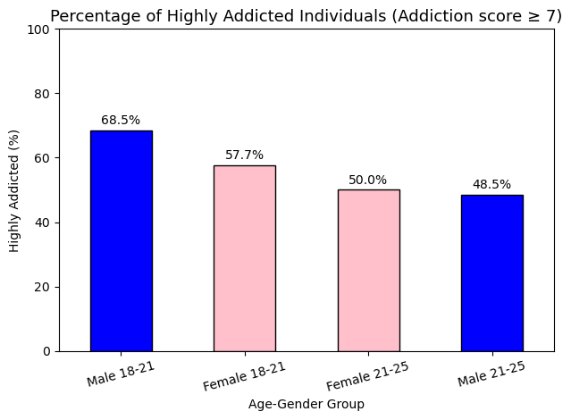

```python
colors = ['pink' if 'Female' in group else 'blue' for group in grouped_Percentage_addicts.sort_values(ascending=False).index]

# ציור הגרף
bars = grouped_Percentage_addicts.sort_values(ascending=False).plot(
    kind='bar',
    color=colors,
    edgecolor='black'
)

# הוספת טקסט עם אחוזים מעל כל עמודה
for i, value in enumerate(grouped_Percentage_addicts.sort_values(ascending=False)):
    plt.text(i, value + 1, f"{value:.1f}%", ha='center', va='bottom', fontsize=10)

plt.title("Percentage of Highly Addicted Individuals (Addiction score ≥ 7)", fontsize=13)
plt.ylabel("Highly Addicted (%)")
plt.xlabel("Age-Gender Group")
plt.ylim(0, 100)
plt.xticks(rotation=15)
plt.tight_layout()
plt.show()
```

כעת נבדוק את שיעור המכורים לפי רמה לימודית באותו דרך

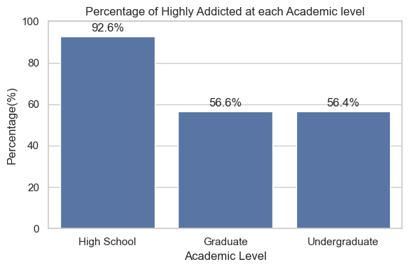

```python
# חישוב אחוז המכורים לפי רמת לימודים מתוך כלל הדאטה
academic_addiction_ratio = df.groupby('Academic_Level')['Is_Highly_Addicted'].mean().sort_values(ascending=False) * 100

# הגדרות עיצוב
sns.set(style="whitegrid")
plt.figure(figsize=(6, 4))

# ציור הגרף
ax = sns.barplot(x=academic_addiction_ratio.index, y=academic_addiction_ratio.values)
ax.set_title("Percentage of Highly Addicted at each Academic level")
ax.set_ylabel("Percentage(%)")
ax.set_xlabel("Academic Level")
ax.set_ylim(0, 100)

# תוויות ערך על כל עמודה
for container in ax.containers:
    ax.bar_label(container, fmt='%.1f%%', padding=3)

plt.tight_layout()
plt.show()
```

### מסקנות:

- גיל ומגדר: אחוז המכורים ביותר נמצא בקרב גברים בני 18-21, בעוד שבגילאים הבוגרים יותר המדד מתאזן כמעט לחלוטין ללא הבדל מגדרי.
- רמה לימודית: בכל רמה לימודית רוב הסטונדטים הם מכורים כאלה שקיבלו ציון שבע ומעלה
- רמה לימודית: אחוז המכורים ביותר נמצא בקרב תלמידי תיכון

## לסיכום

- במסגרת העבודה ניתחנו את השפעת השימוש במדיה החברתית על אורח החיים והביצועים האקדמיים של סטודנטים, תוך מיקוד בזיהוי קבוצות הנמצאות בסיכון גבוה להתמכרות — כגון צעירים, משתמשים כבדים, ובפרט כאלה שהפלטפורמה העיקרית שלהם היא טיקטוק. מטרת הניתוח הייתה להבין טוב יותר את הקשר שבין הרגלי שימוש לבין השפעות על התפקוד היומיומי והלימודי, ולבחון כיצד ניתן לזהות מגמות בעייתיות באוכלוסיות שונות.
- מעבר להיבט התוכני, העבודה תרמה לנו גם מבחינה מקצועית: היא חיזקה את היכולת לנתח ולהציג נתונים בצורה מעמיקה בעזרת ספריות פייתון מגוונות, והעניקה כלים חשובים לעבודה עם דאטה במצבים אמיתיים